# ICY0006 Probability Theory and Statistics

## Project - Medical Cost Personal Datasets

### STAGE 1

#### Step 1

Read your dataset. Done

#### Step 2

Write a description of your dataset:

• What is the topic?

• Where you get it from?

• What kind of variables you have (numerical/categorical etc)?

Describe the variables (the meaning of those).

#### Step 3

Look for missing values, or errors (NA etc) in the dataset.

#### Step 4

Do some data visualization (distribution graphs).

#### Step 5

Describe what you can see from those graphs

*Medical Cost Personal Datasets*

The dateset was used from https://www.kaggle.com/mirichoi0218/insurance

Short Descriptions of variables:

The independent variable is manipulated by the experimenter and its effects on the dependent variable are measured.

Qualitative variables (categorical variables) are those that express a qualitative attribute such as hair colour, eye colour, religion, favourite movie, gender, and so on.

Quantitative variables are those variables that are measured in terms of numbers (height, weight, shoe size).

Discrete variables can take only certain values (For example, a household could have three children or six children, but not 4.53 children)

Continuous variables can take any value within the range of the scale (For example, “time to respond to a question” are continuous variables since the scale is continuous,say, the response time could be 1.64 seconds).

The dataset consist of 1338 observations and 7 variables.

AGE - independent, qualitative and discrete

SEX - categorical, qualitative

BMI - independent continuous variable, quantitative

Nr of CHILDREN - independent discrete variable, qualitative

SMOKER - independent variable, categorical

REGION - independent variable, categorical

CHARGES -dependent continuous variable, quantitative

#### Step 3

```r
which(is.na(insurance))
```

```
integer(0)
```

The return is 0, means Dataset is complete.

#### Step 4 and 5

```r
str(insurance)
```

```
'data.frame':   1338 obs. of  7 variables:
 $ age     : int  19 18 28 33 32 31 46 37 37 60 ...
 $ sex     : chr  "female" "male" "male" "male" ...
 $ bmi     : num  27.9 33.8 33 22.7 28.9 ...
 $ children: int  0 1 3 0 0 0 1 3 2 0 ...
 $ smoker  : chr  "yes" "no" "no" "no" ...
 $ region  : chr  "southwest" "southeast" "southeast" "northwest" ...
 $ charges : num  16885 1726 4449 21984 3867 ...
```

Now we will visualize each variable separately. For that we can use the Density plots.

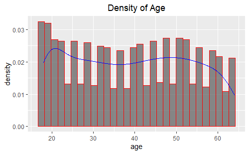

```r
insurance <- read.csv("insurance.csv", header = TRUE, sep = ",")
ggplot(insurance, aes(age)) +
geom_histogram(aes(y=..density..), alpha = 0.7, col = "red") +
geom_density(col = "blue") +
labs(title = "Density of Age") +
theme(plot.title = element_text(hjust = 0.5))
```

Now we can visualize charges distribution based on Age, to see the correlation between the variables.

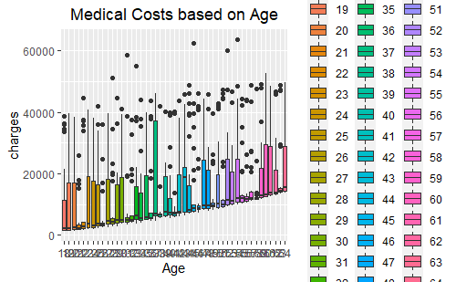

```r
# medical costs for the Age variable
ggplot(insurance, aes(x = as.factor(age), y = charges, fill = as.factor(age))) +
geom_boxplot() +
labs(title = "Medical Costs based on Age",
x = "Age") +
theme(plot.title = element_text(hjust = 0.5))
```

```
Ignoring unknown aesthetics: stat
```

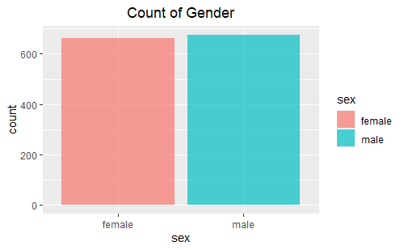

```r
# Visualizing of Gender
ggplot(insurance, aes(x = sex, fill = sex)) +
geom_bar(aes(stat = "identity"), alpha = 0.7) +
labs(title = "Count of Gender") +
theme(plot.title = element_text(hjust = 0.5))
```

```r
table(insurance$sex)
```

```
female   male
   662    676
```

Now we can visualize charges distributions vs gender.

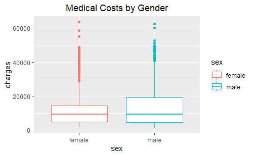

```r
ggplot(insurance, aes(x = sex, y = charges, color = sex)) +
geom_boxplot() +
labs(title = "Medical Costs by Gender") +
theme(plot.title = element_text(hjust = 0.5))
```

```r
      #    legend.position = "none")
```

Based on this plot we can see that there no big difference in charges distributions based on Gender.

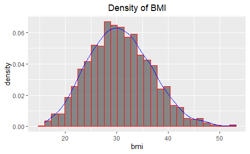

```r
# Density table of BMI
ggplot(insurance, aes(bmi)) +
geom_histogram(aes(y=..density..), alpha = 0.7, col = "red") +
geom_density(col = "blue") +
labs(title = "Density of BMI") +
theme(plot.title = element_text(hjust = 0.5))
```

BMI histogram indicates the normal distribution with single symmetrical pick. Now it will be interesting to see if BMI will have an effect on our Medical charges. Based on the following website https://www.cancer.org/cancer/cancer-causes/diet-physical-activity/body-weight-and-cancer-risk/adult-bmi.html we have an official data on BMI description (This data will help us to analize our table): Underweight: BMI is less than 18.5 Normal weight: BMI is 18.5 to 24.9 Overweight: BMI is 25 to 29.9 Obese: BMI is 30 or more

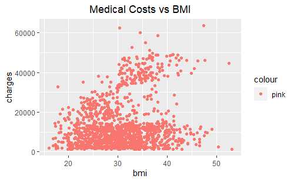

```r
#plot charges vs bmi
ggplot(insurance, aes(x = bmi, y = charges, colour = "pink")) +
geom_point() +
labs(title = "Medical Costs vs BMI") +
theme(plot.title = element_text(hjust = 0.5))
```

```r
NA
```

Based on this plot we can see that charges are growing with BMI increasing. The highest charges we have where BMI over 30 and based on our data above it means that these people are obese. Please note that it is not the main factor, but definitely plays the role.

```r
table(insurance$children)
```

```
  0   1   2   3   4   5
574 324 240 157  25  18
```

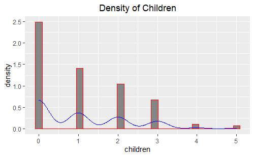

```r
#Density of Children
ggplot(insurance, aes(children)) +
geom_histogram(aes(y=..density..), alpha = 0.7, col = "red") +
geom_density(col = "blue") +
labs(title = "Density of Children") +
theme(plot.title = element_text(hjust = 0.5))
```

Based on the Table we can see that 574 people doesn’t have any children and 18 people have the maximum of 5 children in this Dataset. Now we will try to see if children have an effect on the Medical Charges. Logically we would think that the more children someone has the higher the medical charges, interesting will be to test this assumption (based at least on this dataset)

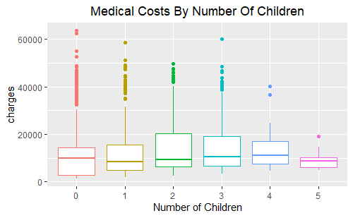

```r
# medical costs for Number of Children
ggplot(insurance, aes(x = as.factor(children), y = charges, color = as.factor(children))) +
geom_boxplot() +
labs(title = "Medical Costs By Number Of Children",
x = "Number of Children") +
theme(plot.title = element_text(hjust = 0.5),
legend.position = "none")
```

Based on this plot we can see that our assumption is not correct and number of children might not be the valuable factor in the increasing the Medical Charges (based on our data). In other scenarios where sample groups for people with 5 children will be big enough we might see different result.

```r
#Count table of Smoker
table(insurance$smoker)
```

```
  no  yes
1064  274
```

```
Ignoring unknown aesthetics: stat
```

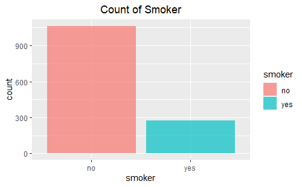

```r
# Visualizing Smoker
ggplot(insurance, aes(x = smoker, fill = smoker)) +
geom_bar(aes(stat = "identity"), alpha = 0.7) +
labs(title = "Count of Smoker") +
theme(plot.title = element_text(hjust = 0.5))
```

Now we can try to see if person smokes how it will affect our distribution cost.

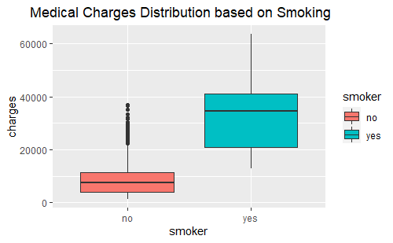

```r
#distribution of charges based on Smoking or not
ggplot(insurance, aes(x = smoker, y = charges, fill = smoker)) +
geom_boxplot()+
labs(title = "Medical Charges Distribution based on Smoking") +
theme(plot.title = element_text(hjust = 0.8))
```

Based on our plot we can see that if person smokes it has very significant factor for increasing the Medical charges.

```r
table(insurance$region)
```

```
northeast northwest southeast southwest
      324       325       364       325
```

```
Ignoring unknown aesthetics: stat
```

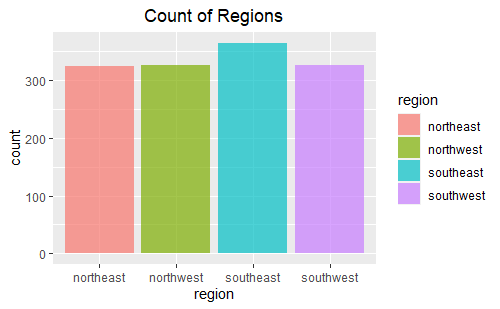

```r
# visualizing Regions
ggplot(insurance, aes(x = region, fill = region)) +
geom_bar(aes(stat = "identity"), alpha = 0.7) +
labs(title = "Count of Regions") +
theme(plot.title = element_text(hjust = 0.5))
```

Now we can try to see if region is important predictor in our model or not.

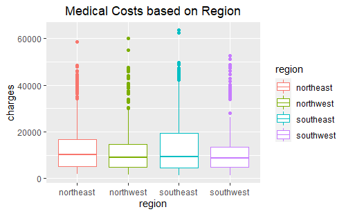

```r
ggplot(insurance, aes(x = region, y = charges, color = region)) +
geom_boxplot() +
labs(title = "Medical Costs based on Region") +
theme(plot.title = element_text(hjust = 0.5))
```

Based on our plot there are no significant differences based on the charges for the particular regions in our dataset.

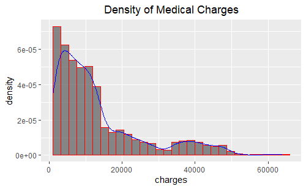

```r
ggplot(insurance, aes(charges)) +
geom_histogram(aes(y=..density..), alpha = 0.7, col = "red") +
geom_density(col = "blue") +
labs(title = "Density of Medical Charges") +
theme(plot.title = element_text(hjust = 0.5))
```

On this distribution we can see that it is right skewed and has two peaks. The first peak is around 2-3k and the second, much smaller pick, is around 40k. Charges histogram is a right-skewed distribution or so called positively skewed distribution. Large portion of data values occur on the left side with a fewer number of data values on the right side.

Summary Age, smoking and bmi variables have the highest impact on the medical charges. Gender, number of children and region have the lowest impact on the medical charges.

## STAGE 2

#### Step 1

Do some quantitive overview

- compute central tendency measures (mean, mode, median, etc)

Central Tendency- is a typical or central value for a probability distribution. It is a descriptive summary of a dataset through a single value that reflects the center of the data distribution. Although it does not provide information regarding the individual values in the dataset, it delivers a comprehensive summary of the whole dataset.

Mean

It is the sum of all values divided by the total number of values. It shows the balance point in the distribution. For discrete variables mean values we can convert to integer.

Median

It is the middle number in an ordered data set.

```r
summary(insurance$age)
```

```
   Min. 1st Qu.  Median    Mean
  18.00   27.00   39.00   39.21
3rd Qu.    Max.
  51.00   64.00
```

```r
summary(insurance$bmi)
```

```
   Min. 1st Qu.  Median    Mean
  15.96   26.30   30.40   30.66
3rd Qu.    Max.
  34.69   53.13
```

```r
summary(insurance$children)
```

```
   Min. 1st Qu.  Median    Mean
  0.000   0.000   1.000   1.095
3rd Qu.    Max.
  2.000   5.000
```

```r
summary(insurance$charges)
```

```
   Min. 1st Qu.  Median    Mean
   1122    4740    9382   13270
3rd Qu.    Max.
  16640   63770
```

Mode The mode is the value that has highest number of occurrences in a set of data. Unlike mean and median, mode can have both numeric and character data (the most frequent value.).

```r
# Create the function.
getmode <- function(v) {
  uniqv <- unique(v)
  uniqv[which.max(tabulate(match(v, uniqv)))]
}

getmode(insurance$region)
```

```
[1] "southeast"
```

```r
getmode(insurance$sex)
```

```
[1] "male"
```

```r
getmode(insurance$smoker)
```

```
[1] "no"
```

```r
getmode(insurance$age)
```

```
[1] 18
```

```r
getmode(insurance$bmi)
```

```
[1] 32.3
```

```r
getmode(insurance$children)
```

```
[1] 0
```

```r
getmode(insurance$charges)
```

```
[1] 1639.563
```

```r
#Summary of Central Tendency Measures
summary(insurance)
```

```
      age            sex
 Min.   :18.00   Length:1338
 1st Qu.:27.00   Class :character
 Median :39.00   Mode  :character
 Mean   :39.21
 3rd Qu.:51.00
 Max.   :64.00
      bmi           children
 Min.   :15.96   Min.   :0.000
 1st Qu.:26.30   1st Qu.:0.000
 Median :30.40   Median :1.000
 Mean   :30.66   Mean   :1.095
 3rd Qu.:34.69   3rd Qu.:2.000
 Max.   :53.13   Max.   :5.000
    smoker             region
 Length:1338        Length:1338
 Class :character   Class :character
 Mode  :character   Mode  :character



    charges
 Min.   : 1122
 1st Qu.: 4740
 Median : 9382
 Mean   :13270
 3rd Qu.:16640
 Max.   :63770
```

Trimean

It is an estimate of central tendency, and is calculated as a weighted average of the median and the two quartiles of a set of values (weighted average of 25th, 50th and 75th percentils)

- compute variability measures (Range, IQR, Standard Deviation, Variance)

Range

The diffrence between the highest and lowest values

```r
range(insurance$age)
```

```
[1] 18 64
```

```r
range(insurance$bmi)
```

```
[1] 15.96 53.13
```

```r
range(insurance$children)
```

```
[1] 0 5
```

```r
range(insurance$charges)
```

```
[1]  1121.874 63770.428
```

Interquartile Range

The interquartile range (IQR) contains the second and third quartiles, or the middle half of the data set. Whereas the range gives the spread of the whole data set, the interquartile range gives the range of the middle half of a data set.

```r
IQR(insurance$age)
```

```
[1] 24
```

```r
IQR(insurance$bmi)
```

```
[1] 8.3975
```

```r
IQR(insurance$children)
```

```
[1] 2
```

```r
IQR(insurance$charges)
```

```
[1] 11899.63
```

Standard Deviation

Average distance from the mean. A high standard deviation means that values are generally far from the mean, while a low standard deviation indicates that values are clustered close to the mean. Standard deviation is a useful measure of spread for normal distributions.

```r
head(insurance)
```

|  | age | sex | bmi | children | smoker | region | charges |
| --- | --- | --- | --- | --- | --- | --- | --- |
| 1 | 19 | female | 27.900 | 0 | yes | southwest | 16884.924 |
| 2 | 18 | male | 33.770 | 1 | no | southeast | 1725.552 |
| 3 | 28 | male | 33.000 | 3 | no | southeast | 4449.462 |
| 4 | 33 | male | 22.705 | 0 | no | northwest | 21984.471 |
| 5 | 32 | male | 28.880 | 0 | no | northwest | 3866.855 |
| 6 | 31 | female | 25.740 | 0 | no | southeast | 3756.622 |

```r
# or we can use the following formula:
  sqrt(var(insurance))
```

```
NAs introduced by coercion
```

```
                 age sex         bmi   children smoker
age       14.0499604  NA   3.0597936  0.8481172     NA
sex               NA  NA          NA         NA     NA
bmi        3.0597936  NA   6.0981869  0.3062593     NA
children   0.8481172  NA   0.3062593  1.2054927     NA
smoker            NA  NA          NA         NA     NA
region            NA  NA          NA         NA     NA
charges  225.5544331  NA 121.0260484 31.5067327     NA
         region     charges
age          NA   225.55443
sex          NA          NA
bmi          NA   121.02605
children     NA    31.50673
smoker       NA          NA
region       NA          NA
charges      NA 12110.01123
```

Variance

Average of squared distances from the mean.

```r
var(insurance)
```

```
NAs introduced by coercion
```

```
                  age sex          bmi     children
age      1.974014e+02  NA 9.362337e+00   0.71930275
sex                NA  NA           NA           NA
bmi      9.362337e+00  NA 3.718788e+01   0.09379476
children 7.193027e-01  NA 9.379476e-02   1.45321275
smoker             NA  NA           NA           NA
region             NA  NA           NA           NA
charges  5.087480e+04  NA 1.464730e+04 992.67420324
         smoker region      charges
age          NA     NA 5.087480e+04
sex          NA     NA           NA
bmi          NA     NA 1.464730e+04
children     NA     NA 9.926742e+02
smoker       NA     NA           NA
region       NA     NA           NA
charges      NA     NA 1.466524e+08
```

#### Step 2

Write a summary

- What can you use from those central tendency/ variability measures?
- Does it corresponds to visual picture of distribution?
- What you can conclude from this analysis?

While a measure of central tendency describes the typical value, measures of variability define how far away the data points tend to fall from the center. The variability in the context of a distribution of values. The conclusion is that data sets could have the same central tendency, but different levels of variability or vice versa. Together they give us complete picture of our data. The variability measures corresponds nicely with our visualizations of the distribution and give exact values that sometimes are hard to see from the visual representation.

## Stage 3

#### Step 1

Try to find out, if there are some linear relationships between variables:

- Pick up only those variable, which are suitable. Remove outliers if required.
- Compute correlation matrix. It would be nice if you can express it visually.

To find out the linear relationship between the variables, we will choose suitable variables like age, bmi, children and charges. First we have to remove outliers. Outliers are data points that fall far away from the major “cluster” of points. They can be legit data points carrying valuable information or can be erroneous values altogether. There are multiple ways on how to detect potential Outliers. The most notable ones are The Inter Quartile Range method and the z-score method. We will use IQR method to detect outliers and boxplot to visualize the outliers.

```r
#we can use visualization to check for outliers by using boxplot

par(mfrow = c(1,3))
par("mar")
```

```
[1] 5.1 4.1 2.1 2.1
```

[figure not shown]

```r
par(mar=c(1,1,1,1))
boxplot(insurance$age, main = "Boxplot of Age")
boxplot(insurance$bmi, main = "Boxplot of BMI")
```

```r
# removing outliers with IQR
# find Q1, Q3 and IQR for values in column Age
Q1 <-quantile(insurance$bmi, .25)
Q3 <- quantile(insurance$bmi, .75)
IQR <- IQR(insurance$bmi)
# only keep rows that have values within 1.5*IQR of Q1 and Q3
insurance_2 <- subset(insurance, insurance$bmi> (Q1 - 1.5*IQR) & insurance$bmi< (Q3 + 1.5*IQR))
#we can compare to the original value that was 1338
str(insurance_2)
```

```
'data.frame':   1329 obs. of  7 variables:
 $ age     : int  19 18 28 33 32 31 46 37 37 60 ...
 $ sex     : chr  "female" "male" "male" "male" ...
 $ bmi     : num  27.9 33.8 33 22.7 28.9 ...
 $ children: int  0 1 3 0 0 0 1 3 2 0 ...
 $ smoker  : chr  "yes" "no" "no" "no" ...
 $ region  : chr  "southwest" "southeast" "southeast" "northwest" ...
 $ charges : num  16885 1726 4449 21984 3867 ...
```

```r
par(mfrow = c(1,3))
par("mar")
```

```
[1] 5.1 4.1 2.1 2.1
```

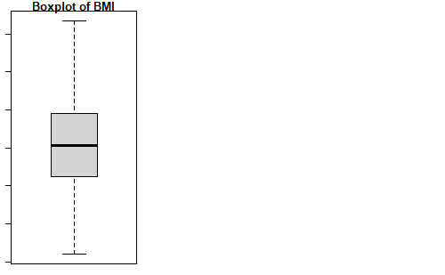

```r
par(mar=c(1,1,1,1))
boxplot(insurance_2$bmi, main = "Boxplot of BMI")
```

We can see that outliers were removed from our bmi boxplot and now we have 1329 observations instead of 1338.

*Correlation matrix*

Correlation matrix showing the relationship between two or more variables and the interrelation in their movements. The matrix depicts the correlation between all the possible pairs of values in a table. It consists of rows and columns that show the variables. Each cell in a table contains the correlation coefficient. The correlation coefficient’s values range between -1.0 and 1.0. Based on Pearson’s correlation value table we can better understand the relationship between the variables:

0- No correlation -0.2 to 0 /0 to 0.2 – very weak negative/ positive correlation -0.4 to -0.2/0.2 to 0.4 – weak negative/positive correlation -0.6 to -0.4/0.4 to 0.6 – moderate negative/positive correlation -0.8 to -0.6/0.6 to 0.8 – strong negative/positive correlation -1 to -0.8/0.8 to 1 – very strong negative/positive correlation -1/1 – perfectly negative/positive correlation

```r
#correlation values
library("corrplot")
cor(insurance_2[sapply(insurance_2, is.numeric)])
```

```
                age       bmi   children    charges
age      1.00000000 0.1146860 0.04304057 0.30202178
bmi      0.11468605 1.0000000 0.01735450 0.19319613
children 0.04304057 0.0173545 1.00000000 0.06973923
charges  0.30202178 0.1931961 0.06973923 1.00000000
```

Based on our values (rounded values): - First cell is always be 1 because it represents the relationship between the same variable (we are not interested in that kind of relationship). BMI/age - 0.11 - Children/age - 0.04 Charges/age - 0.3 bmi/children - 0.02 bmi/charges - 0.19 children/charges - 0.07 Based on our values we have the highest positive correlation between age and charges, which is 0.3. The other relationships that note to mention are bmi/charges, which is approx 0.2. And the slight relationship we can see between the bmi and age, which is 0.1.

```r
#Correlation matrix visualization
library(GGally)
library("corrplot")
mat_1 <- as.matrix(cor((insurance_2[sapply(insurance_2, is.numeric)])))
mat_1
```

```
                age       bmi   children    charges
age      1.00000000 0.1146860 0.04304057 0.30202178
bmi      0.11468605 1.0000000 0.01735450 0.19319613
children 0.04304057 0.0173545 1.00000000 0.06973923
charges  0.30202178 0.1931961 0.06973923 1.00000000
```

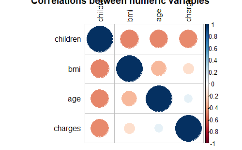

```r
corrplot(cor(mat_1), title = "Correlations between numeric variables", order="hclust", tl.col="black")
```

#### Step 2

Pay attention to dependent variable:

- From correlation analysis you know which variables have high correlation with your dependent variable.
- Draw the scatter plots “Dependent variable vs independent variable”
- Write down your observations Based on our correlation analyses and scatter plot, we can conclude that these two variables share a common covariance and are homoscedastic.

From the our correlation matrix we can see the charges variable is our dependent variable, so we will create the scatterplots for charges vs age/bmi/children (not categorical variables)

But first I would like to make the scatterplot for all the variables (except charges) to view the relationship between the categorical variables as well.

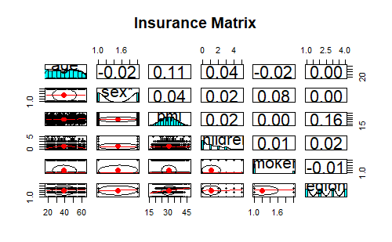

```r
#we can also create another version of complete Scatter plot matrix
library(psych)
pairs.panels(insurance_2[c("age", "sex", "bmi", "children", "smoker", "region")], digits = 2, cor = TRUE, main = "Insurance Matrix")
```

In the scatterplot matrix: - red dot shows the mean - oval means more correlation and if circle is more round then less correlation. Based on the plot above, we can see that there are no strong correlations between these variables, r < 0.2

We will proceed now to create our scatterplots for the highest correlations, charges vs age/bmi/children

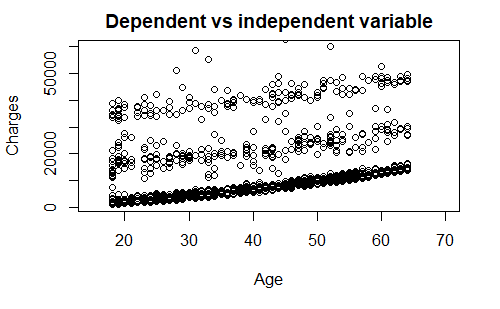

```r
#Age vs charges
input <- insurance_2[,c('age','charges')]

plot(x = input$age, y = input$charges,
     xlab = "Age",
     ylab = "Charges",
     xlim = c(15, 70),
     ylim = c(1000,60000),
     main = "Dependent vs independent variable"
)
```

Based on the above scatterplot we can see that charges are in 3 ranges (we saw it already in Stage 1) and steadily increasing with age. We also see: - positive relationship between variables, - smooth increasing slope of the lines, - how tightly the points cluster, specially at the bottom range (this means the linear relationship) - homoscedasticity Meaning there is a pretty moderate relationship between the age and the charges: the older the person the higher the charges.But there some factor, probably due to smoker or not that affecting and creating these ranges

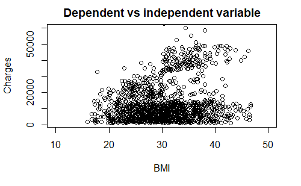

```r
input <- insurance_2[,c('bmi','charges')]

plot(x = input$bmi, y = input$charges,
     xlab = "BMI",
     ylab = "Charges",
     xlim = c(10, 50),
     ylim = c(1000,60000),
     main = "Dependent vs independent variable"
)
```

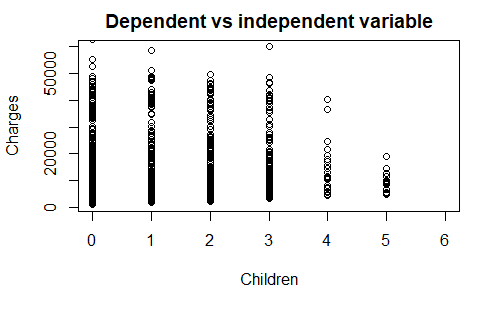

```r
input <- insurance_2[,c('children','charges')]

plot(x = input$children, y = input$charges,
     xlab = "Children",
     ylab = "Charges",
     xlim = c(0, 6),
     ylim = c(1000,60000),
     main = "Dependent vs independent variable"
)
```

## Step 3

Pick up one pair of “dependent variable vs independent variable” - Construct the linear regression model. - Draw the scatter plot “with line” - Write down your observations

Linear Regression is used predict or estimate the value of a dependent variable by modelling it against one or more independent variables. We will look into our liner regression model for the age vs charges with the function and the scatterplot with a line.

```r
#simple linear regression
data <- lm(insurance_2$charges ~ insurance_2$age)
summary(data)
```

```
Call:
lm(formula = insurance_2$charges ~ insurance_2$age)

Residuals:
   Min     1Q Median     3Q    Max
 -8002  -6611  -5884   5393  47886

Coefficients:
                Estimate Std. Error t value Pr(>|t|)
(Intercept)      3100.28     930.70   3.331 0.000889 ***
insurance_2$age   257.93      22.35  11.541  < 2e-16 ***
---
Signif. codes:
0 ‘***’ 0.001 ‘**’ 0.01 ‘*’ 0.05 ‘.’ 0.1 ‘ ’ 1

Residual standard error: 11440 on 1327 degrees of freedom
Multiple R-squared:  0.09122,   Adjusted R-squared:  0.09053
F-statistic: 133.2 on 1 and 1327 DF,  p-value: < 2.2e-16
```

```r
sigma(data)/mean(insurance_2$charges)
```

```
[1] 0.865955
```

F-statistic - Used to estimate the significance of a regression model as a whole. The higher the parameter value, the better it is. Our value is 133.2, which is good.

t value - A criteria based on the Student’s t distribution. The value of the parameter in linear regression indicates the significance of the factor; it is generally accepted that at t> 2 the factor is significant for the model.

p value - This is the probability that the hypothesis that the independent variables do not explain the dynamics of the dependent variable is true zero. If the p value is below the threshold (.05 or .01 for the most demanding), then the null hypothesis is false. The lower the better:-)

In our plot the p-value is 2.2e-16, which is 2.2 X 10 ^ -16 If we test with 95% confidence or 5% significance, our P-value of 2.2 X 10 ^-16 is very less compared to 5%=0.05. So we will reject the null hypothesis

Our prediction equation: charges = 3100 + 258 * age

```r
# we need to convert the smoker variable  from categorical to numerical, because it is affecting our main correlation pair

insurance_2$smoker <- as.factor(insurance_2$smoker)
```

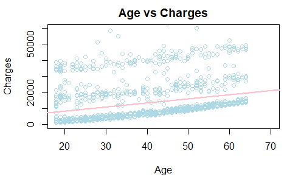

```r
#scatterplot with the line
simple_lin <- insurance_2[,c('age','charges')]
plot(x = input$age, y = input$charges,
     xlab = "Age",
     ylab = "Charges",
     xlim = c(18, 70),
     ylim = c(0,60000),
     main = "Age vs Charges",
     col = "lightblue")

abline(lm(input$charges ~ input$age, data = insurance_2), col="pink", lwd=2)
```

```r
linearReg <- lm(input$age ~ input$charges, data = insurance_2)
print(linearReg)
```

```
Call:
lm(formula = input$age ~ input$charges, data = insurance_2)

Coefficients:
  (Intercept)  input$charges
    3.453e+01      3.536e-04
```

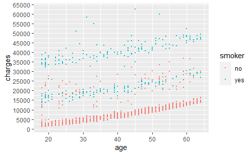

```r
# we are creating the scatterplot in different colors to be able to see why do we have 3 ranges in age vs charges relationship and which other variable affecting it.
ggplot(insurance_2, aes(age,charges, col=smoker)) + geom_point(size=0.5) + scale_y_continuous(breaks = seq(0,65000,5000))
```

Based on the scatterplots above we see that at the bottom layer of our linear relationship we have very nice, smooth increase in charges with age, for people who doesn’t smoke (red dots). Then at the middle and upper layer we can say that charges increased a lot for the smokers (green dots). Because of influence of smoker variable on our strongest correlation pair our regression line is passing slightly above the main set of values. Later on we will see the reason for it. Still the regression line is very useful for forecasting our procedures. It is showing the interrelation of our dependent (y) variable with our independent(x) variable.

Further in multiple regression we will analyze it in more details.

#### Step 4

**Multiple Regression**

- Try regression with several variables, if possible.
- Additional: try other regression algorithms.

```r
#multiple regression
#compute the model coefficients (all x variables)
multiple_model <- lm(charges ~ age + sex + bmi + children + smoker + region, data = insurance_2)
summary(multiple_model)
```

```
Call:
lm(formula = charges ~ age + sex + bmi + children + smoker +
    region, data = insurance_2)

Residuals:
     Min       1Q   Median       3Q      Max
-11491.4  -2913.2   -980.3   1458.5  30172.3

Coefficients:
                 Estimate Std. Error t value Pr(>|t|)
(Intercept)     -11961.25    1004.86 -11.903  < 2e-16 ***
age                256.49      11.87  21.603  < 2e-16 ***
sexmale            -41.45     331.43  -0.125  0.90049
bmi                339.27      29.26  11.597  < 2e-16 ***
children1          440.22     420.24   1.048  0.29504
children2         1656.33     464.90   3.563  0.00038 ***
children3          989.35     544.30   1.818  0.06935 .
children4         2938.62    1230.02   2.389  0.01703 *
children5         1102.27    1445.15   0.763  0.44576
smokeryes        23629.99     413.23  57.184  < 2e-16 ***
regionnorthwest   -412.26     473.40  -0.871  0.38400
regionsoutheast  -1049.09     476.98  -2.199  0.02802 *
regionsouthwest  -1012.88     475.43  -2.130  0.03332 *
---
Signif. codes:  0 ‘***’ 0.001 ‘**’ 0.01 ‘*’ 0.05 ‘.’ 0.1 ‘ ’ 1

Residual standard error: 6013 on 1316 degrees of freedom
Multiple R-squared:  0.7511,    Adjusted R-squared:  0.7488
F-statistic: 330.9 on 12 and 1316 DF,  p-value: < 2.2e-16
```

```r
#The error rate can be estimated by dividing the RSE by the mean outcome variable
sigma(multiple_model)/mean(insurance_2$charges)
```

```
[1] 0.4551175
```

The first step in interpreting the multiple regression analysis is to examine the F-statistic and the associated p-value.

In our plot, it can be seen that p-value of the F-statistic is < 2.2e-16 for the Age, which is highly significant. This means that, Age, smoker and bmi. Age variable is one of the predictor variables that significantly related to the outcome variable. Smoker is categorical variable, so we would use it just to show the influence on the age vs charges relationship.

We have a decent R2 of 0.7511, which implies 75% of the variation of charges could be explained by our set of included independent variables.

```r
#compute the model coefficients
model <- lm(charges ~ age + smoker + bmi, data = insurance_2)
summary(model)
```

```
Call:
lm(formula = charges ~ age + smoker + bmi, data = insurance_2)

Residuals:
   Min     1Q Median     3Q    Max
-12230  -2993  -1019   1411  29128

Coefficients:
             Estimate Std. Error t value Pr(>|t|)
(Intercept) -11698.29     951.08  -12.30   <2e-16 ***
age            258.81      11.90   21.75   <2e-16 ***
smokeryes    23627.95     411.89   57.36   <2e-16 ***
bmi            325.71      28.22   11.54   <2e-16 ***
---
Signif. codes:
0 ‘***’ 0.001 ‘**’ 0.01 ‘*’ 0.05 ‘.’ 0.1 ‘ ’ 1

Residual standard error: 6048 on 1325 degrees of freedom
Multiple R-squared:  0.7464,    Adjusted R-squared:  0.7459
F-statistic:  1300 on 3 and 1325 DF,  p-value: < 2.2e-16
```

```r
#The error rate can be estimated by dividing the RSE by the mean outcome variable
sigma(model)/mean(insurance_2$charges)
```

```
[1] 0.4577621
```

To assess model accuracy, we have to take a look at other values like R2 and RSE (residual standard error or sigma)

The RSE estimate gives a measure of error of prediction. The lower the RSE, the more accurate the model. Corresponding to 45% error rate, it is much better than in the simple model, where RSE was 86% error rate.

In multiple linear regression, the R2 represents the correlation coefficient between the observed values of the outcome variable (y) and the fitted (i.e., predicted) values of y. For this reason, the value of R will always be positive and will range from zero to one. R2 represents the proportion of variance, in the outcome variable y, that may be predicted by knowing the value of the x variables. An R2 value close to 1 indicates that the model explains a large portion of the variance in the outcome variable. In our case it is 0.74 The adjustment in the “Adjusted R Square” value in the summary output is a correction for the number of x variables included in the prediction model. In our plot, with age and bmi predicator variables, the adjusted R2 = 0,74, meaning that "74% of the variance in the measure of charges can be predicted by age, smoker and bmi. In comparison, this model is much better than our simple liner regression model with only age, which had an adjusted R2 of 0.09.

Now we can try recreate our scatterplot with the regression line and see how it will pass when we include our variables with the highest correlation.

```r
#compute and visualize the scatterplot with the regression line (charges, age, smoker)

model3 <- lm(charges ~ age+smoker, insurance_2)
summary(model3)
```

```
Call:
lm(formula = charges ~ age + smoker, data = insurance_2)

Residuals:
   Min     1Q Median     3Q    Max
-15871  -2057  -1347   -228  28980

Coefficients:
            Estimate Std. Error t value Pr(>|t|)
(Intercept) -2368.98     525.53  -4.508 7.13e-06 ***
age           274.55      12.39  22.153  < 2e-16 ***
smokeryes   23627.66     431.94  54.701  < 2e-16 ***
---
Signif. codes:  0 ‘***’ 0.001 ‘**’ 0.01 ‘*’ 0.05 ‘.’ 0.1 ‘ ’ 1

Residual standard error: 6342 on 1326 degrees of freedom
Multiple R-squared:  0.7209,    Adjusted R-squared:  0.7205
F-statistic:  1713 on 2 and 1326 DF,  p-value: < 2.2e-16
```

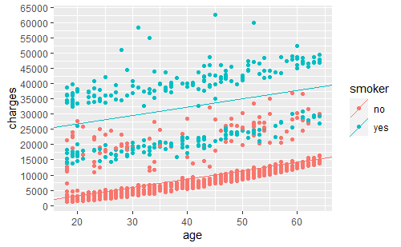

```r
intercepts <- c(coef(model3)["(Intercept)"], coef(model3)["(Intercept)"] +
coef(model3)["smokeryes"])
lines.df <- data.frame(intercepts = intercepts,
slopes  = rep(coef(model3)["age"], 2),
smoker = levels(insurance_2$smoker))
qplot(x = age, y = charges, color = smoker, data = insurance_2) +
geom_abline(aes(intercept = intercepts, slope = slopes, color =smoker),
data = lines.df) + scale_y_continuous(breaks = seq(0,65000,5000))
```

```r
#The error rate can be estimated by dividing the RSE by the mean outcome variable
sigma(model3)/mean(insurance_2$charges)
```

```
[1] 0.4800395
```

Based on our scatterplot above we can see that we 2 parallel lines, which means we have two regression equations having the same slope, but different intercepts. Slope of the regression line we can see in column with Estimate values for the variable age - 274.55. Intercept for the smoker is much higher than for non smoker, 23627.66. Meaning of it is that medical charges for the smoker is higher by $23k (approx) than for the person who doesn’t smoke. Of course the age will be considered as well, but the charges are very much depend on if the person smokes or not.

To summarize all of the above. The RSE value lowest in the model with all the variables 45%, the next model with slighlty higher RSE is the model with charges/age/smoker/bmi and with a little bit higher RSE 48% is the model with charges/age/smoker. Other variables like sex and region are very insignificant in affecting the outcome of the charges variable. So based on all the analyses above we can conclude that multiple regression model with charges/age/smoker/bmi provides the most valuable evaluation parameters.

## Stage 4

Step 1

- Pick up a lottery. For example, https://www.eurojackpot.com/ etc. Do not pick up bingo type lotteries.
- Describe the lottery.
- Describe the winning condition Step 2 Compute the probabilities of winning for each case. For example, as in here https://en.wikipedia.org/wiki/Eurojackpot

Step 3 Explain your computation.

Step 4 Write a small report on that.

I am not familiar with lottery games. So I searched for the most popular lotteries in the world (https://www.wonderslist.com/top-10-best-lottery-games-world/) I decided to go with US Powerball.

Based on the rules, you must select five numbers from a pool between 1 and 69 and one Powerball between 1 and 26. The Powerball you select can be the same as one of the five main numbers. If you match all five numbers and the Powerball, you win the top prize. By guessing just the main numbers and not the Powerball, you can qualify for the $1 million second prize. The order of the balls is not important, so for my calculations I will use combinations and not permutations.

***C(69,5) = 69!/(5!(69-5)!) = 11238513 So, probability of the wining the prize if you guess 5 numbers is 1/11238513 ≈= 0.000000089 And there are 26 ways to select the Powerball, so resulting in 26 x 11238513 = 292201338 possible selections. The probability to win the main prize, by guessing all 6 numbers is 1/292201338

We can calculate the rest of the possibilities

***Guessing all five balls but not the Powerball:

25/292201338 ≈= 0.0000000856

***Guessing four of the five balls and the Powerball:

C(5,4) = 5 ways to guess four of the five. The 5th ball is one of the remaining 64 that were not drawn, so C(64,1) = 64 ways for this to happen. There is only 1 way to guess Powerball. 5 x 64 x 1 = 320 ways to guess four of the five balls and Powerball. Probability of this to happen is 320/292201338 ≈= 0.0000010951

***Guessing four of the five balls but not the Powerball:

C(5,4) = 5 ways to guess four of the five. The 5th ball is one of the remaining 64 that were not drawn, so C(64,1) = 64 ways for this to happen. This time, there 25 ways to not guess the Powerball. 5 x 64 x 25 = 8000 ways to guess four of the five balls and not the Powerball. Probability of this to happen is 8000/292201338 ≈= 0.0000273784

***Guessing three of the five balls and the Powerball:

C(5,3) = 10 ways to guess three of the five. The remaining balls are the ones of the remaining 64 that were not drawn, so C(64,2) = 2016 ways for this to happen. There is only one way to guess Powerball. 10 x 2016 x 1 = 20160 ways to guess three of the five balls and Powerball. Probability of this to happen is 20160/292201338 ≈= 0.0000689935

***Guessing three of the five balls but not the Powerball:

C(5,3) = 10 ways to guess three of the five. The remaining balls are the ones of the remaining 64 that were not drawn, so C(64,2) = 2016 ways for this to happen. This time, there 25 ways to not guess the Powerball. 10 x 2016 x 25 = 504000 ways to guess three of the five balls and not the Powerball. Probability of this to happen is 504000/292201338 ≈= 0.0017248381

***Guessing two of the five balls and the Powerball:

C(5,2) = 10 ways to guess two of the five. The remaining balls are the ones of the remaining 64 that were not drawn, so C(64,3) = 41664 ways for this to happen. There is only one way to guess Powerball. 10 x 41664 x 1 = 416640 ways to guess two of the five balls and Powerball. Probability of this to happen is 416640/292201338 ≈= 0.0014258662

***Guessing one of the five balls and the Powerball:

C(5,4) = 5 ways to guess one of the five. The remaining balls are the ones of the remaining 64 that were not drawn, so C(64,4) = 635376 ways for this to happen. There is only one way to guess Powerball. 5 x 635376 x 1 = 3176880 ways to guess one of the five balls and Powerball. Probability of this to happen is 3176880/292201338 ≈= 0.0108722295

Guessing just the Powerball, but none of the other balls:

It is possible to win if non of five balls guessed, but only Powerball guessed. So C(64,5) = 7624512 ways for this to happen. There is only one way to guess Powerball. Meaning that we have 7624512 ways not to guess any balls except for the Powerball. Probability of this to happen is 7624512/292201338 ≈= 0.0260933507

After calculating the above probabilities of the winning in the US Powerball lottery, I think everyone can see that the chance to win the main price is so small that it is close to impossible. Very nice exercise!

## Stage 5

#### Step 1

- Split your dataset into two sets: training and testing sets.
- This splitting must be done randomly (if you don’t have timeseries as part of the set, when the process is more complicated)
- The proportions can be different, for example 80/20, 70/30, 90/10, where the bigger part is the training set, and the smaller part - testing set.

When we built our linear regression model based on full dataset it is hard to predict how it will perform with new data. So we will split our dataset into a 80/20 sample (training/ test). Later, by calculating accuracy measures (like min_max accuracy) and error rates (MAPE or MSE), we will see the prediction accuracy of the model.

```r
#creating the training and testing data
# setting seed to reproduce results of random sampling
set.seed(100)
trainingRowIndex <- sample(1:nrow(insurance_2), 0.8*nrow(insurance_2))
train <- insurance_2[trainingRowIndex, ]
test <- insurance_2[-trainingRowIndex, ]

#Training Data
str(train)
```

```
'data.frame':   1063 obs. of  7 variables:
 $ age     : int  37 26 51 43 19 56 59 19 63 22 ...
 $ sex     : Factor w/ 2 levels "female","male": 2 1 2 2 1 2 2 1 2 2 ...
 $ bmi     : num  30.9 19.8 27.7 23.2 29.8 ...
 $ children: Factor w/ 6 levels "0","1","2","3",..: 4 2 2 1 1 3 1 1 4 3 ...
 $ smoker  : Factor w/ 2 levels "no","yes": 1 1 1 1 1 2 1 1 1 2 ...
 $ region  : Factor w/ 4 levels "northeast","northwest",..: 2 4 1 4 4 3 1 4 4 3 ...
 $ charges : num  6797 3379 9958 6250 1744 ...
```

```r
summary(train)
```

```
      age            sex           bmi        children smoker          region       charges
 Min.   :18.00   female:525   Min.   :16.82   0:453    no :835   northeast:258   Min.   : 1122
 1st Qu.:27.00   male  :538   1st Qu.:26.10   1:263    yes:228   northwest:251   1st Qu.: 4788
 Median :39.00                Median :30.50   2:191              southeast:290   Median : 9386
 Mean   :39.12                Mean   :30.54   3:124              southwest:264   Mean   :13502
 3rd Qu.:51.00                3rd Qu.:34.69   4: 18                              3rd Qu.:17528
 Max.   :64.00                Max.   :46.75   5: 14                              Max.   :62593
```

```r
#Test date
str(test)
```

```
'data.frame':   266 obs. of  7 variables:
 $ age     : int  32 46 37 37 56 30 37 55 23 19 ...
 $ sex     : Factor w/ 2 levels "female","male": 2 1 1 2 1 1 2 1 2 1 ...
 $ bmi     : num  28.9 33.4 27.7 29.8 39.8 ...
 $ children: Factor w/ 6 levels "0","1","2","3",..: 1 2 4 3 1 2 3 3 2 6 ...
 $ smoker  : Factor w/ 2 levels "no","yes": 1 1 1 1 1 1 1 1 1 1 ...
 $ region  : Factor w/ 4 levels "northeast","northwest",..: 2 3 2 1 3 4 2 2 2 4 ...
 $ charges : num  3867 8241 7282 6406 11091 ...
```

```r
summary(test)
```

```
      age            sex           bmi        children smoker          region      charges
 Min.   :18.00   female:134   Min.   :15.96   0:118    no :223   northeast:65   Min.   : 1243
 1st Qu.:26.00   male  :132   1st Qu.:26.71   1: 57    yes: 43   northwest:74   1st Qu.: 4657
 Median :40.00                Median :30.07   2: 47              southeast:67   Median : 9295
 Mean   :39.55                Mean   :30.52   3: 33              southwest:60   Mean   :12054
 3rd Qu.:52.00                3rd Qu.:33.89   4:  7                             3rd Qu.:13426
 Max.   :64.00                Max.   :46.70   5:  4                             Max.   :48674
```

We can see that our Training set contains 1063 observations and Test set has 266 observations. Also with summary function we can see the values for the particular column. We can easily compare them between the training and the testing sets.

#### Step 2

- Train the regression model on training set.
- You can use different sets of features (if possible), with one or more variables.
- You can train different types of the models (if you wish to try more), but at least you need to try linear regression.

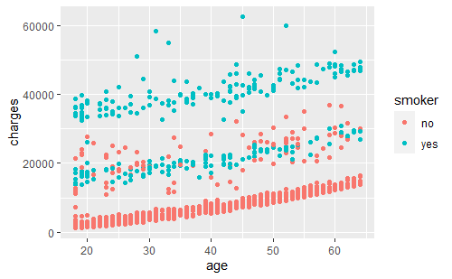

```r
#visualizing our first model
ggplot(data= insurance_2)+geom_point(aes(x=age,y=charges,color=smoker))
```

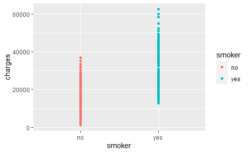

```r
ggplot(data= insurance_2)+geom_point(aes(x=smoker,y=charges,color=smoker))
```

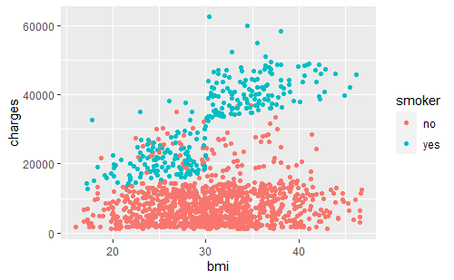

```r
ggplot(data= insurance_2)+geom_point(aes(x=bmi,y=charges,color=smoker))
```

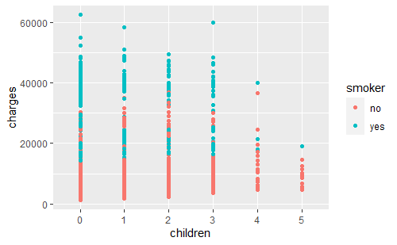

```r
ggplot(data= insurance_2)+geom_point(aes(x=children,y=charges,color=smoker))
```

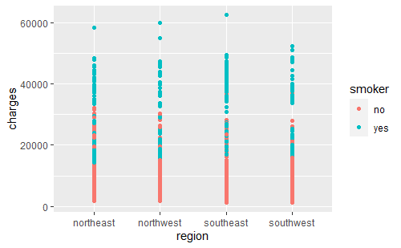

```r
ggplot(data= insurance_2)+geom_point(aes(x=region,y=charges,color=smoker))
```

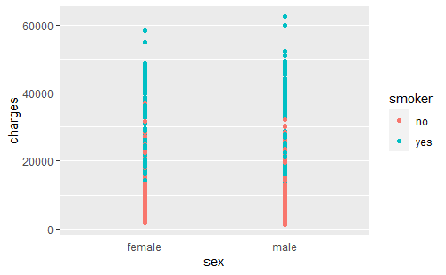

```r
ggplot(data= insurance_2)+geom_point(aes(x=sex,y=charges,color=smoker))
```

```r
NA
NA
```

```r
#build the model on the training set
#computing and visualizing the training set
model5 <- lm(charges ~ age + smoker +bmi + region + children + sex, data = train)
summary(model5)
```

```
Call:
lm(formula = charges ~ age + smoker + bmi + region + children +
    sex, data = train)

Residuals:
   Min     1Q Median     3Q    Max
-11189  -3148  -1000   1686  30026

Coefficients:
                 Estimate Std. Error t value             Pr(>|t|)
(Intercept)     -12543.27    1160.90 -10.805 < 0.0000000000000002 ***
age                255.58      13.71  18.646 < 0.0000000000000002 ***
smokeryes        23645.29     467.69  50.557 < 0.0000000000000002 ***
bmi                360.31      33.47  10.766 < 0.0000000000000002 ***
regionnorthwest   -201.56     550.42  -0.366              0.71429
regionsoutheast   -822.72     545.95  -1.507              0.13213
regionsouthwest   -919.71     545.54  -1.686              0.09212 .
children1          476.08     481.02   0.990              0.32253
children2         1549.06     535.66   2.892              0.00391 **
children3         1014.38     632.82   1.603              0.10925
children4         1717.84    1491.02   1.152              0.24953
children5          431.23    1689.13   0.255              0.79855
sexmale           -152.17     382.26  -0.398              0.69066
---
Signif. codes:  0 ‘***’ 0.001 ‘**’ 0.01 ‘*’ 0.05 ‘.’ 0.1 ‘ ’ 1

Residual standard error: 6196 on 1050 degrees of freedom
Multiple R-squared:  0.7465,    Adjusted R-squared:  0.7437
F-statistic: 257.7 on 12 and 1050 DF,  p-value: < 0.00000000000000022
```

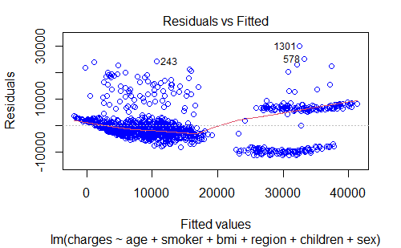

```r
# residuals vs fitted values helps us to detect non-linearity, unequal error variances, and outliers.
plot(model5, which = 1, col = "blue")
```

#### Step 3

- Test you model on testing set.
- Evaluate how “well” your model performs.
- For that you can apply different metrics (MAPE, RMSE, MAE, etc.)
- If it is possible, change the type of the model or set of features, and compare the results.
- Write report.

Now we can calculate prediction accuracy and error rate. A higher correlation accuracy implies that the actuals and predicted values have similar directional movement.

```r
#predict the  first model
pred1 <- predict(model5, test)
actuals_preds1 <- data.frame(cbind(actuals = test$charges, predicted = pred1))
cor(actuals_preds1)
```

```
            actuals predicted
actuals   1.0000000 0.8766801
predicted 0.8766801 1.0000000
```

MinMaxAccuracy = mean(min(actuals, predicteds)/max(actuals, predicteds)

```r
#Min-Max Calculations
min_max_accuracy <- mean(apply(actuals_preds1, 1, min) / apply(actuals_preds1, 1, max))
min_max_accuracy
```

```
[1] 0.7084675
```

MeanAbsolutePercentageError(MAPE) = mean(abc(predicteds?actuals)/actuals)

```r
#MAPE Calculations
mape <- mean(abs((actuals_preds1$predicted - actuals_preds1$actuals))/actuals_preds1$actuals)
mape
```

```
[1] 0.401781
```

We can compute all other error metrics with DMwR function

```r
DMwR::regr.eval(actuals_preds1$actuals, actuals_preds1$predicted)
```

```
            mae             mse            rmse            mape
    3651.797185 27710226.476482     5264.050387        0.401781
```

The Mean Absolute Error (MAE) is a very good to measure forecast accuracy, it represents the difference between the original and predicted values extracted by squared the average difference over the data set. The Root Mean Squared Error (RMSE) is defined as the square root of the average squared error. MAPE is the sum of the individual absolute errors divided by the demand (each period separately). It is the average of the percentage errors.

*Model 2*

```r
#improvements
# convertion to numeric values
insurance_new <- insurance_2
insurance_new$smoker = as.factor(insurance_new$smoker)
insurance_new$smoker = as.numeric(insurance_new$smoker)
insurance_new$children = as.factor(insurance_new$children)
insurance_new$children = as.numeric(insurance_new$children)
insurance_new$region = as.factor(insurance_new$region)
insurance_new$region = as.numeric(insurance_new$region)
insurance_new$bmi30 <- ifelse(insurance_new$bmi >= 30, 1, 0)
```

```r
# Create Training and Test data -- model2 (after the improvements)
trainingRowIndex <- sample(1:nrow(insurance_new), 0.8 * nrow(insurance_new))
train2 <- insurance_new[trainingRowIndex,]
test2 <- insurance_new[-trainingRowIndex,]


#view
str(train2)
```

```
'data.frame':   1063 obs. of  8 variables:
 $ age     : int  64 63 58 50 33 63 45 35 61 23 ...
 $ sex     : Factor w/ 2 levels "female","male": 1 1 2 1 1 2 2 1 2 2 ...
 $ bmi     : num  23 36.9 25.2 27.6 19.1 ...
 $ children: num  1 1 1 2 3 1 6 2 1 1 ...
 $ smoker  : num  2 1 1 2 2 1 1 1 1 1 ...
 $ region  : num  3 3 1 4 1 4 3 4 1 3 ...
 $ charges : num  27038 13888 11931 24520 16776 ...
 $ bmi30   : num  0 1 0 0 0 1 0 1 1 1 ...
```

```r
summary(train2)
```

```
      age            sex           bmi           children         smoker          region         charges
 Min.   :18.00   female:534   Min.   :17.20   Min.   :1.000   Min.   :1.000   Min.   :1.000   Min.   : 1122
 1st Qu.:26.00   male  :529   1st Qu.:26.32   1st Qu.:1.000   1st Qu.:1.000   1st Qu.:2.000   1st Qu.: 4553
 Median :39.00                Median :30.36   Median :2.000   Median :1.000   Median :3.000   Median : 9282
 Mean   :39.11                Mean   :30.59   Mean   :2.074   Mean   :1.196   Mean   :2.516   Mean   :13006
 3rd Qu.:51.00                3rd Qu.:34.43   3rd Qu.:3.000   3rd Qu.:1.000   3rd Qu.:3.000   3rd Qu.:16112
 Max.   :64.00                Max.   :46.75   Max.   :6.000   Max.   :2.000   Max.   :4.000   Max.   :62593
     bmi30
 Min.   :0.0000
 1st Qu.:0.0000
 Median :1.0000
 Mean   :0.5287
 3rd Qu.:1.0000
 Max.   :1.0000
```

```r
#view test data for second model
str(test2)
```

```
'data.frame':   266 obs. of  8 variables:
 $ age     : int  37 19 56 34 63 63 53 61 53 29 ...
 $ sex     : Factor w/ 2 levels "female","male": 2 2 2 1 1 2 1 1 1 1 ...
 $ bmi     : num  29.8 24.6 40.3 31.9 23.1 ...
 $ children: num  3 2 1 2 1 1 2 3 4 2 ...
 $ smoker  : num  1 1 1 2 1 1 2 1 1 1 ...
 $ region  : num  1 4 4 1 1 2 3 4 4 3 ...
 $ charges : num  6406 1837 10602 37702 14452 ...
 $ bmi30   : num  0 0 1 1 0 0 0 1 0 0 ...
```

```r
summary(test2)
```

```
      age            sex           bmi           children         smoker          region        charges
 Min.   :18.00   female:125   Min.   :15.96   Min.   :1.000   Min.   :1.000   Min.   :1.00   Min.   : 1141
 1st Qu.:27.00   male  :141   1st Qu.:25.76   1st Qu.:1.000   1st Qu.:1.000   1st Qu.:2.00   1st Qu.: 5920
 Median :42.00                Median :30.16   Median :2.000   Median :1.000   Median :2.00   Median :10169
 Mean   :39.57                Mean   :30.33   Mean   :2.184   Mean   :1.237   Mean   :2.50   Mean   :14037
 3rd Qu.:50.00                3rd Qu.:34.91   3rd Qu.:3.000   3rd Qu.:1.000   3rd Qu.:3.75   3rd Qu.:17884
 Max.   :64.00                Max.   :46.70   Max.   :6.000   Max.   :2.000   Max.   :4.00   Max.   :48885
     bmi30
 Min.   :0.0000
 1st Qu.:0.0000
 Median :1.0000
 Mean   :0.5113
 3rd Qu.:1.0000
 Max.   :1.0000
```

```r
# Build the model on training data
model6 <- lm(charges ~ age + smoker + bmi30 + region + children + sex, data = train2)
summary(model6)
```

```
Call:
lm(formula = charges ~ age + smoker + bmi30 + region + children +
    sex, data = train2)

Residuals:
     Min       1Q   Median       3Q      Max
-13192.6  -3397.1    -80.5   1172.6  27918.8

Coefficients:
            Estimate Std. Error t value             Pr(>|t|)
(Intercept) -27864.7      938.5 -29.691 < 0.0000000000000002 ***
age            270.5       13.0  20.801 < 0.0000000000000002 ***
smoker       23737.7      464.6  51.092 < 0.0000000000000002 ***
bmi30         3933.3      371.4  10.590 < 0.0000000000000002 ***
region        -362.1      166.9  -2.170              0.03024 *
children       455.7      152.8   2.983              0.00292 **
sexmale       -411.0      369.1  -1.113              0.26578
---
Signif. codes:  0 ‘***’ 0.001 ‘**’ 0.01 ‘*’ 0.05 ‘.’ 0.1 ‘ ’ 1

Residual standard error: 5980 on 1056 degrees of freedom
Multiple R-squared:  0.7534,    Adjusted R-squared:  0.752
F-statistic: 537.8 on 6 and 1056 DF,  p-value: < 0.00000000000000022
```